# lab3

tommaso tarchi

2022-11-11

## interval estimation for normal distribution

### theory

For the mean of a normal distribution, we can compute the interval estimation with confidence level 0.95 (i. e. $\alpha=0.05$) using the usual pivotal quantity T and then check how accurate the estimate actually is:

```r
set.seed(1234)

#normal case with sigma^2 known (consider mu = 5 and sigma = 2 and n = 10)
B <- 1000
n <- 10
mu <- 5
sigma <- 2

# 1-alpha is the confidence level
alpha <- 0.05
# CI is matrix where we save the confidence intervals for each replication:
# -) first column: lower bound
# -)  second column: upper bound
CI <- matrix(NA, B, 2)

# l is a vector whose elements assume TRUE (1) or FALSE(0) depending on whether the true parameter value lies within the interval
l <- rep(NA, B)

# qualtile of the standard normal
q0975 <- qnorm(1 - alpha/2)

for (i in 1:B) {
  CI[i, ] <- mean(rnorm(n, mu, sigma)) + c(-1, 1)*sigma*q0975/sqrt(n)
  l[i] <- CI[i, 1] < mu & CI[i, 2] > mu
}

mean(l)
```

```
## [1] 0.955
```

We now plot the first 100 c.i.:

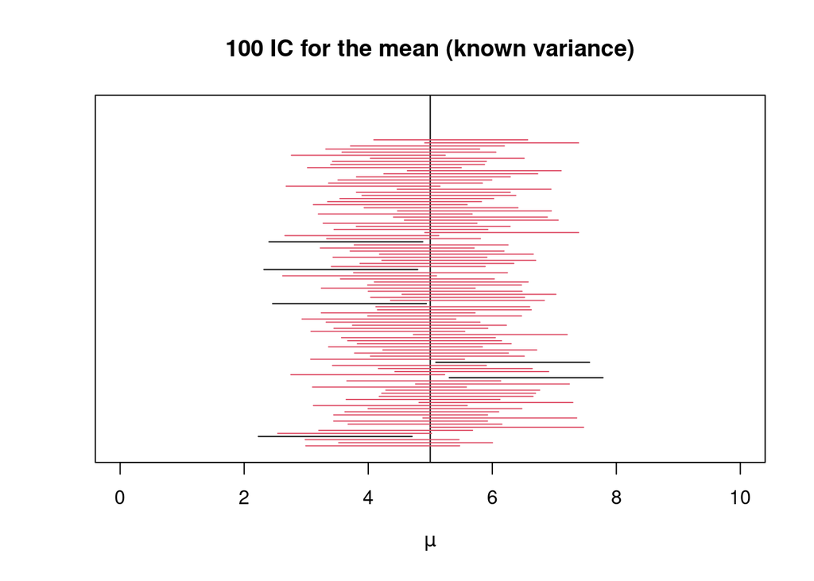

```r
# black: intervals that not include mu
# red: intervals that include mu

plot(1, xlim = c(0, 10), ylim = c(0, 11), type = "n",
     xlab = expression(mu), ylab = "", yaxt  = "n",
     main = paste("100 IC for the mean (known variance)"), cex.main = 1.2)
abline(v = mu)

d <- 0
for ( i in 1 : 100 ) {
    d <- d + 0.1
    lines(seq(CI[i, 1], CI[i, 2], length = 100), rep(d, 100), col = (l[i] + 1))
}
```

```r
sum(l[1:100])
```

```
## [1] 94
```

In the case in which also the variance is unknown, we can use the same pivotal quantity with $s$ (sample standard deviation) in place of $\sigma$, which is distributed as a $t_{n-1}$ distribution (which again is symmetric).

### application

We want to estimate the mean of the difference between ‘heated’ and ‘ambient’ in pair65 (we do it for the first n measurements). Since both mean and st. dev. are unknown, we will use the student t distribution:

```r
library(DAAG)
n <- 9
pair_data_frame <- cbind(pair65, pair65[,1] - pair65[,2])
pair_data_frame <- cbind(c(1:n), pair_data_frame)
dimnames(pair_data_frame) <- list(1:n, c("pair","heated", "ambient", "difference"))

# D stands for 'difference'
mD <- mean(pair_data_frame[, 2]) - mean(pair_data_frame[, 3])
sdD <- sqrt(var(pair_data_frame[, 2]) + var(pair_data_frame[, 3])) / sqrt(n)
mD
```

```
## [1] 6.333333
```

```r
mean(pair_data_frame[, 4])
```

```
## [1] 6.333333
```

```r
sdD
```

```
## [1] 7.291336
```

```r
sd(pair_data_frame[, 4]) / sqrt(n)
```

```
## [1] 2.034426
```

```r
# then we just apply the same procedure as above using the student t distribution with n-1 degrees of freedom
```

## hypothesis test

### p-value

```r
# for code see LAB3.html
```

### Pearson’s chi-squared test

Si noti che la frequenza usata nel test di Pearson è quella assoluta, non relativa.

For the darts example with 4 zones on the target, 50 shots and p probabilities of hitting the four zones:

```r
# Initial settings:
# number of attempts n = 50
# number of zones K = 4
# vector of probabilities p = c( 7/16, 5/16, 3/16, 1/16)
n <- 50
K <- 4
p <- c(7/16, 5/16, 3/16, 1/16)

set.seed(1234)
x <- sample(1:K, n, prob = p, replace = TRUE)
x
```

```
##  [1] 1 2 2 2 3 2 1 1 2 2 2 2 1 3 1 3 1 1 1 1 1 1 1 1 1 3 2 3 3 1 2 1 1 2 1 3 1 1
## [39] 4 3 2 2 1 2 1 2 2 2 1 3
```

```r
# observed frequencies
obs <- table(x)
obs
```

```
## x
##  1  2  3  4
## 23 17  9  1
```

```r
# we now perform the test 'by hand' (value is chisq computed on the sample)
X2 <- sum((obs - p*n)^2 / (p*n))
p.value <- pchisq(X2, K-1, lower.tail = FALSE)
p.value
```

```
## [1] 0.6506117
```

Si noti (in riferimento a LAB3) che cambiando le condizioni sperimentali e mantenendo la stessa null hypotesis possiamo controllare se l’ipotesi è più o meno verificata, ma non possiamo capire in che direzione cambiarla.

We now do the example with more than one friend and a great player:

```r
# why xn is not working properly while x2 is?

set.seed(123)

# number of friends
M <- 6
pg <- c(1/16, 3/16, 5/16, 7/16)

# x for friends and x_great for great player
x <- matrix(0, M, n)
for (i in 1:M)  x[i, ] <- sample(1:K, n, replace = TRUE, prob = p)
x_great <- sample(1:K, n, replace = TRUE, prob = pg)

obs <- apply(x, 1, table)
obs <- cbind(obs, table(x_great))
obs
```

```
##   [,1] [,2] [,3] [,4] [,5] [,6] [,7]
## 1   21   23   22   21   23   25    3
## 2   15   14   16   21   17   11    8
## 3    9   12    7    7    6   11   17
## 4    5    1    5    1    4    3   22
```

```r
chisq.test(obs, p = p)
```

```
##
##  Pearson's Chi-squared test
##
## data:  obs
## X-squared = 88.166, df = 18, p-value = 3.077e-11
```